# Indel Signature InsDel9

# InsDel9

**Note**

The XCT -> XT deletions may be related to APOBEC activity.

(corresponds to 83-type signature C_ID9)

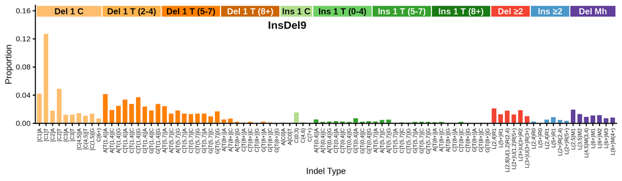

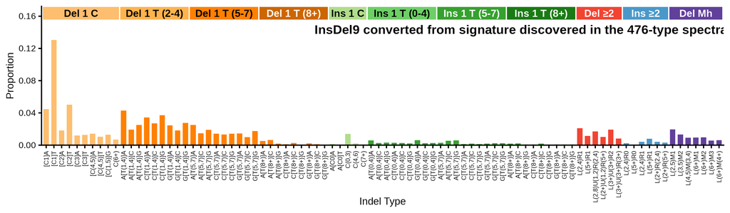

89-type spectrum of the linking tumor SP102617 | cosine similarity to InsDel9: 0.9259

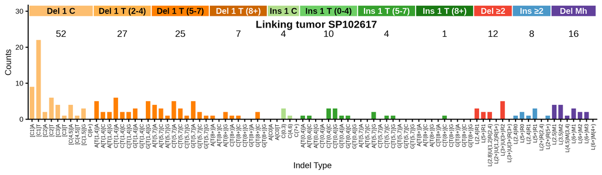

**Click to view decomposition of the linking tumor spectrum**

Partial mutation signature of SP102617 due to InsDel9

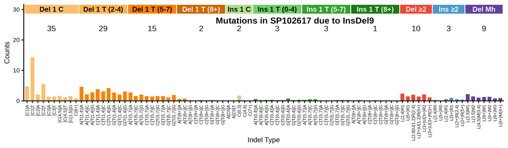

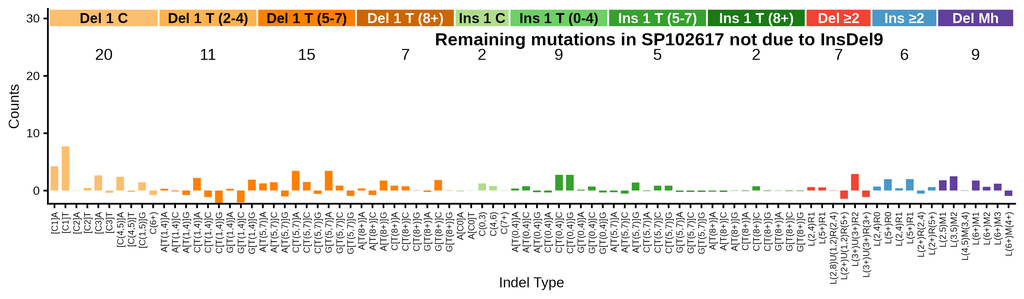

Max neg fraction (maximum allowed negative residual count as fraction of total): 0.12  
N subtract (mutation count assigned to signature): 112.5  
N residual (mutation count in residual “partial spectrum”): 53.5  
Total negative (sum of negative residual mutation counts): 19.1  
N negative channels (number of channels with negative residual): 42  
P(≥ total negative) (Monte Carlo estimated probability that negative-binomial-sampled spectra from the signature contributing N subtract mutations would produce a total negative count >= the observed Total negative; higher number means not surprising): 0.901

**Per-channel residual breakdown**

| Channel | Spectrum | Sig_Count | Residual | Sig_Prop |
| --- | --- | --- | --- | --- |
| [Del(C):R1]A | 9 | 4.7 | 4.3 | 0.04216 |
| [Del(C):R1]T | 22 | 14.3 | 7.7 | 0.12702 |
| [Del(C):R2]A | 2 | 2.0 | 0 | 0.01812 |
| [Del(C):R2]T | 6 | 5.5 | 0.5 | 0.04923 |
| [Del(C):R3]A | 4 | 1.4 | 2.6 | 0.01214 |
| [Del(C):R3]T | 1 | 1.4 | -0.4 | 0.01247 |
| [Del(C):R(4,5)]A | 4 | 1.6 | 2.4 | 0.01431 |
| [Del(C):R(4,5)]T | 1 | 1.2 | -0.2 | 0.01079 |
| [Del(C):R(1,5)]G | 3 | 1.5 | 1.5 | 0.01359 |
| Del(C):R(6,9) | 0 | 0.8 | -0.8 | 0.00706 |
| A[Del(T):R(1,4)]A | 5 | 4.7 | 0.3 | 0.04154 |
| A[Del(T):R(1,4)]C | 2 | 2.1 | -0.1 | 0.01902 |
| A[Del(T):R(1,4)]G | 2 | 2.8 | -0.8 | 0.02484 |
| C[Del(T):R(1,4)]A | 6 | 3.8 | 2.2 | 0.03380 |
| C[Del(T):R(1,4)]C | 2 | 3.1 | -1.1 | 0.02762 |
| C[Del(T):R(1,4)]G | 2 | 4.2 | -2.2 | 0.03717 |
| G[Del(T):R(1,4)]A | 3 | 2.7 | 0.3 | 0.02395 |
| G[Del(T):R(1,4)]C | 0 | 2.0 | -2 | 0.01821 |
| G[Del(T):R(1,4)]G | 5 | 3.1 | 1.9 | 0.02755 |
| A[Del(T):R(5,7)]A | 4 | 2.7 | 1.3 | 0.02434 |
| A[Del(T):R(5,7)]C | 3 | 1.6 | 1.4 | 0.01386 |
| A[Del(T):R(5,7)]G | 1 | 2.0 | -1 | 0.01814 |
| C[Del(T):R(5,7)]A | 5 | 1.5 | 3.5 | 0.01374 |
| C[Del(T):R(5,7)]C | 3 | 1.5 | 1.5 | 0.01308 |
| C[Del(T):R(5,7)]G | 1 | 1.6 | -0.6 | 0.01381 |
| G[Del(T):R(5,7)]A | 5 | 1.6 | 3.4 | 0.01387 |
| G[Del(T):R(5,7)]C | 2 | 1.1 | 0.9 | 0.00993 |
| G[Del(T):R(5,7)]G | 1 | 1.9 | -0.9 | 0.01696 |
| A[Del(T):R(8,)]A | 1 | 0.6 | 0.4 | 0.00563 |
| A[Del(T):R(8,)]C | 0 | 0.8 | -0.8 | 0.00670 |

[output cut: 59 more lines]

**Click to view similar signatures from Koh et al.**

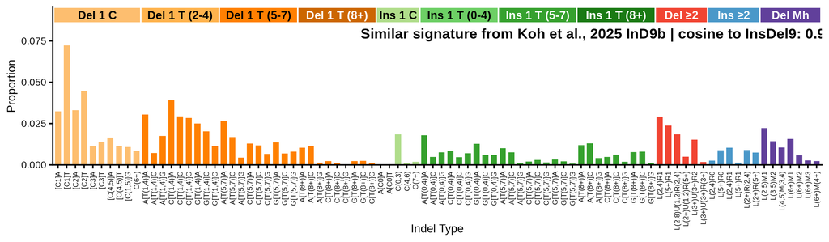

## 476-type representations corresponding to InsDel9

Extracted 476-type signature corresponding to InsDel9

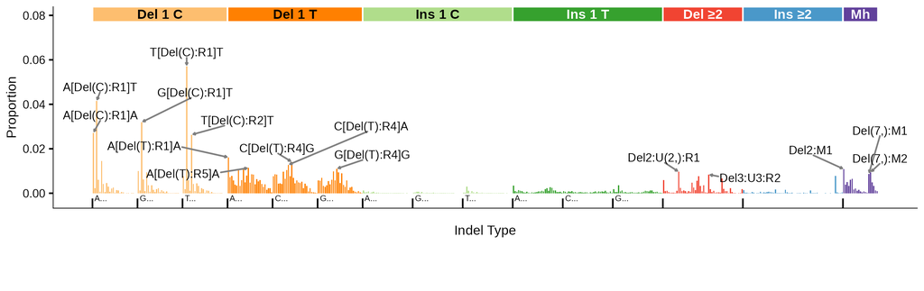

476-type spectrum of the linking tumor SP102617; cosine similarity to the extracted 476-type signature is 0.7921

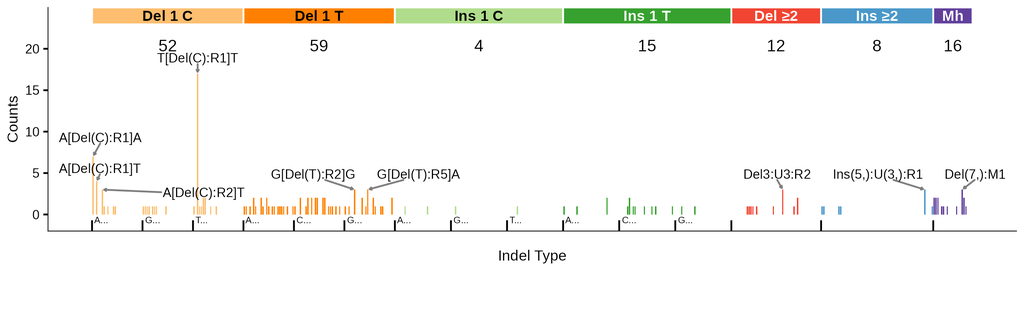

476-type spectrum of best 476-type matching tumor SP116520; cosine similarity to the extracted 476-type signature is 0.8445

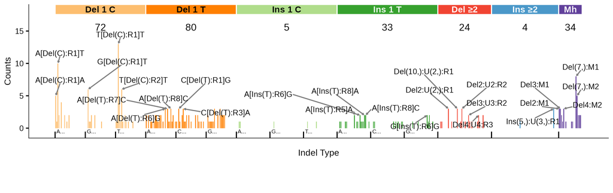

## 83-type signature corresponding to InsDel9 (C_ID9)

**Note**

We believe that the signature C_ID9 that we extracted corresponds to COSMIC signature ID9, even though C_ID9 has a large proportion of deletions of single thymines in long poly-T contexts, which ID9 completely lacks. We believe this an instance of “over splitting” due to all such deletions being allocated to a single mutation type in the 83-type indel classification.

Furthermore, Koh, Nanda, et al.’s extraction of a similar signature from 89-type spectra and our extraction from type-476 spectra that collapse to a similar 89-type signature indicate noticeable proportions of insertions of single Ts in long poly-T contexts.

ID9 also lacks insertions and deletions of sequences longer than 1 base, but these insertions and deletions are present in C_ID9 and in extractions from 89-type and 476-type spectra, which would seem to support C_ID9 versus ID9.

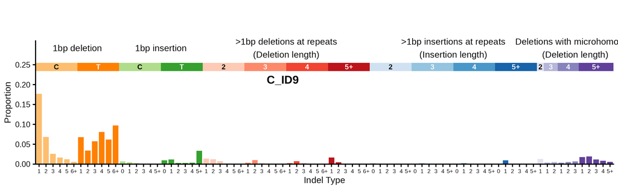

83-type signature converted from signature discovered in the 476-type spectra (using bipartite matching optimization) | cosine similarity to C_ID9: 0.9983

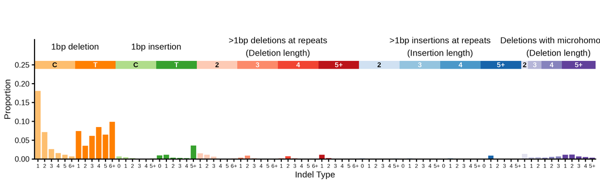

**Click to see flow diagrams: 476-type to 83-type collapse**

These Sankey diagrams show how the 476-type mutation categories are redistributed to 83-type categories using bipartite matching. We only show the diagrams for insertions or deletions of > 1 base because it is for these indels that 476-type categories map to > 1 83-type category.

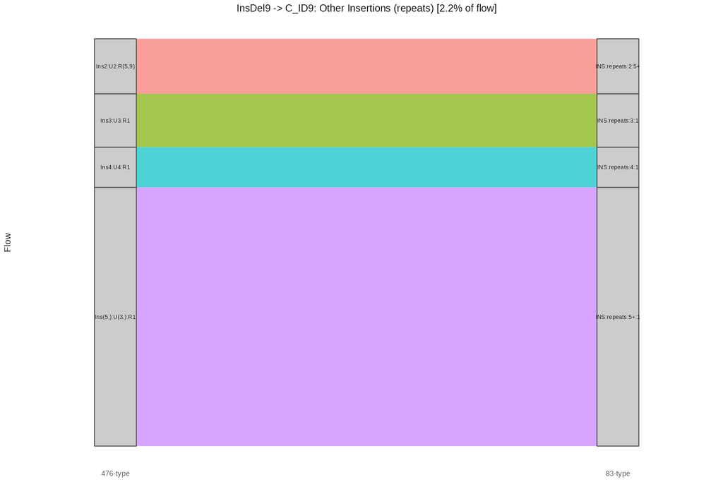

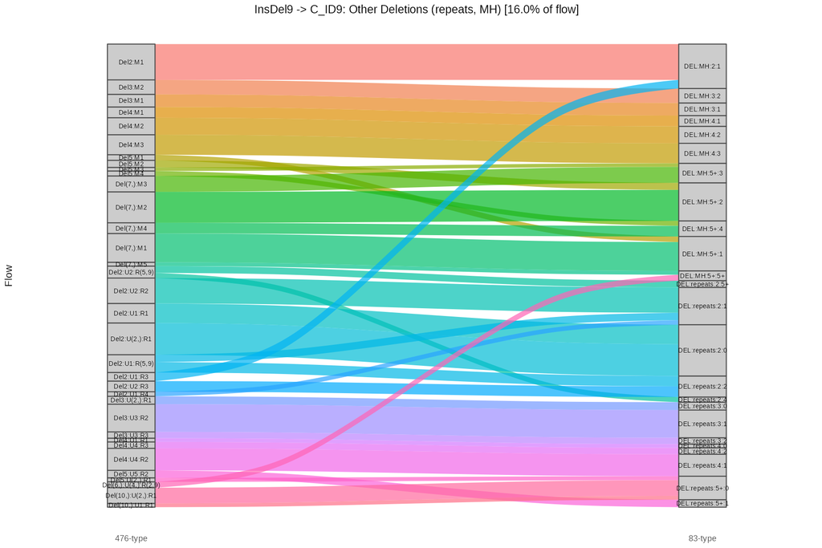

83-type spectrum of the linking tumor SP102617 | cosine similarity to C_ID9: 0.9487

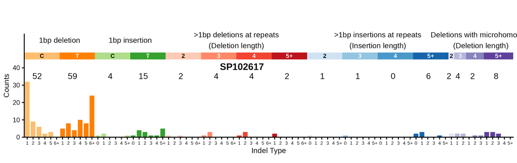